DS 6030 | Fall 2024 | University of Virginia

# Homework #10: Density Estimation

Author

Published

November 27, 2024

# Required R packages and Directories

```r
data_dir = 'https://mdporter.github.io/teaching/data' # data directory
library(ks)        # functions for KDE
library(tidyverse) # functions for data manipulation
```

```r
library(tidyverse)
bat_data = read.csv(file.path(data_dir, "geo_profile.csv"))

bat_data <- bat_data |>
  rename(X = 'X2.5817631825286242')|>
  bind_rows(tibble(X = 3.5))

str(bat_data)
```

```
'data.frame':   283 obs. of  1 variable:
 $ X: num  2.11 5.35 3.87 2.85 2.71 ...
```

# Problem 1 Geographic Profiling

Geographic profiling, a method developed in criminology, can be used to estimate the [home location (roost) of animals](https://www.sciencedirect.com/science/article/pii/S0022519305004157) based on a collection of sightings. The approach requires an estimate of the distribution the animal will travel from their roost to forage for food.

A sample of $283$ distances that pipistrelle bats traveled (in meters) from their roost can be found at:

- **Bat Data**: https://mdporter.github.io/teaching/data/geo_profile.csv

One probability model for the distance these bats will travel is:
$$\begin{align*}
f(x; \theta) = \frac{x}{\theta} \exp \left( - \frac{x^2}{2 \theta} \right)
\end{align*}$$
where the parameter $\theta > 0$ controls how far they are willing to travel.

## a. Derive a closed-form expression for the MLE for $\theta$ (i.e., show the math).

**Solution**

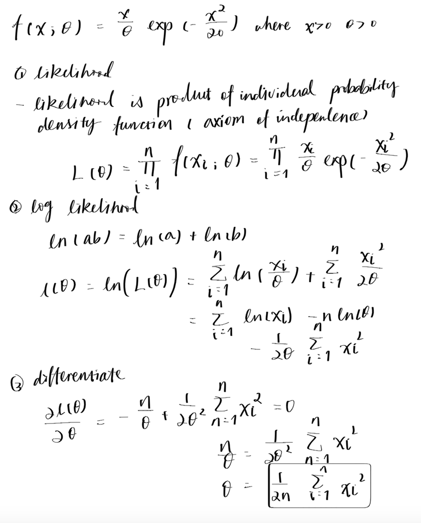

## b. Estimate $\theta$ for the bat data using MLE?

Calculate using the solution to part a, or use computational methods.

**Solution**

```r
distances <- bat_data$X  # Replace 'distance' with the actual column name if different
n <- length(distances)
theta_hat <- (1 / (2 * n)) * sum(distances^2)
theta_hat
```

```
[1] 4.53
```

## c. Plot the estimated density

Using the MLE value of $\theta$ from part b, calculate the estimated density at a set of evaluation points between 0 and 8 meters. Plot the estimated density.

- The x-axis should be distance and y-axis should be density (pdf).

**Solution**

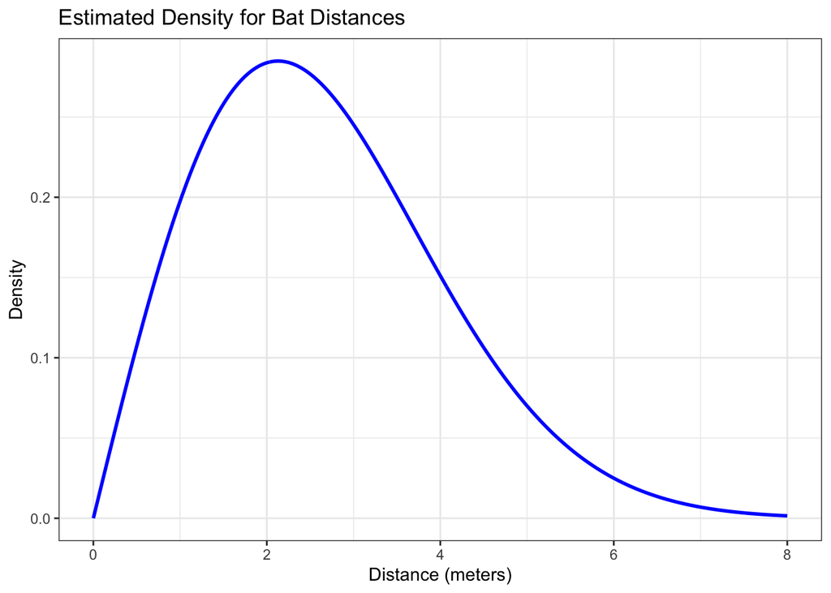

```r
# Define the PDF function
bat_pdf <- function(x, theta) {
  ifelse(x >= 0, (x / theta) * exp(-x^2 / (2 * theta)), 0)
}

# Generate points between 0 and 8 meters
points <- seq(0, 8, length.out = 500)

# Calculate density using theta
density_values <- sapply(points, function(x) bat_pdf(x, theta_hat))

# Create a dataframe
density_data <- data.frame(
  Distance = points,
  Density = density_values
)

# Plotting
ggplot(density_data, aes(x = Distance, y = Density)) +
  geom_line(color = "blue", size = 1) +
  labs(
    title = "Estimated Density for Bat Distances",
    x = "Distance (meters)",
    y = "Density"
  )
```

## d. Estimate the density using KDE.

Report the bandwidth you selected and produce a plot of the estimated density.

**Solution**

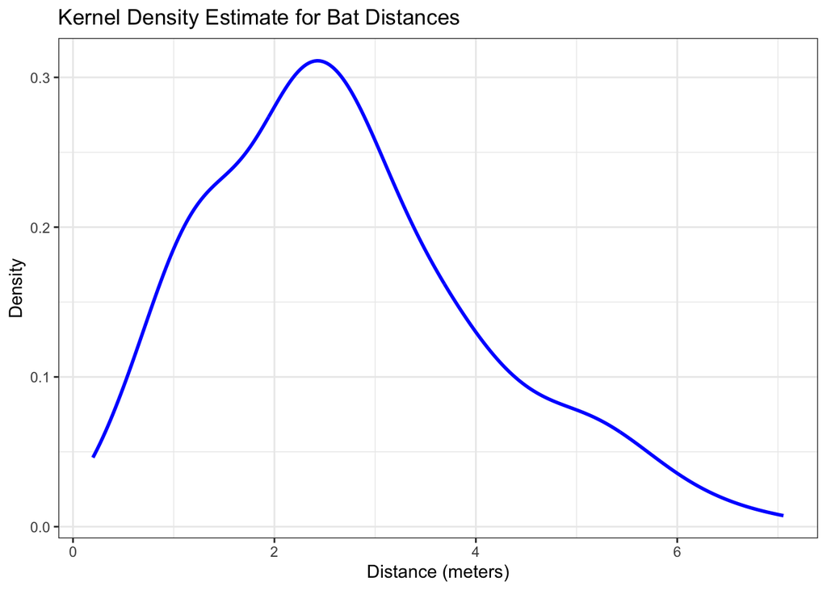

```r
kde_result <- kde(x = distances)
bandwidth <- kde_result$H

# Generate points for plotting
points <- seq(min(distances), max(distances), length.out = 500)

density_estimates <- predict(kde_result, x = points)

density_data <- data.frame(
  Distance = points,
  Density = density_estimates
)

# Plotting
ggplot(density_data, aes(x = Distance, y = Density)) +
  geom_line(color = "blue", size = 1) +
  labs(
    title = "Kernel Density Estimate for Bat Distances",
    x = "Distance (meters)",
    y = "Density"
  )
```

```r
cat("Selected Bandwidth Matrix:\n")
```

```
Selected Bandwidth Matrix:
```

```r
print(bandwidth)
```

```
[1] 0.16
```

## e. Which model do you prefer, the parametric or KDE? Why?

**Solution**

I prefer parametric here because there isn’t much data points and flexibility in the model is not exactly what we are looking for.

# Problem 2: Interstate Crash Density

Interstate 64 (I-64) is a major east-west road that passes just south of Charlottesville. Where and when are the most dangerous places/times to be on I-64? The crash data (link below) gives the mile marker and fractional time-of-week for crashes that occurred on I-64 between mile marker 87 and 136 in 2016. The time-of-week data takes a numeric value of *<dow>.<hour/24>*, where the dow starts at 0 for Sunday (6 for Sat) and the decimal gives the time of day information. Thus `time=0.0417` corresponds to Sun at 1am and `time=6.5` corresponds to Sat at noon.

- **Crash Data**: https://mdporter.github.io/teaching/data/crashes16.csv

## a. Crash Data

Extract the crashes and make a scatter plot with mile marker on x-axis and time on y-axis.

**Solution**

```r
data2 = read.csv(file.path(data_dir, 'crashes16.csv'))
```

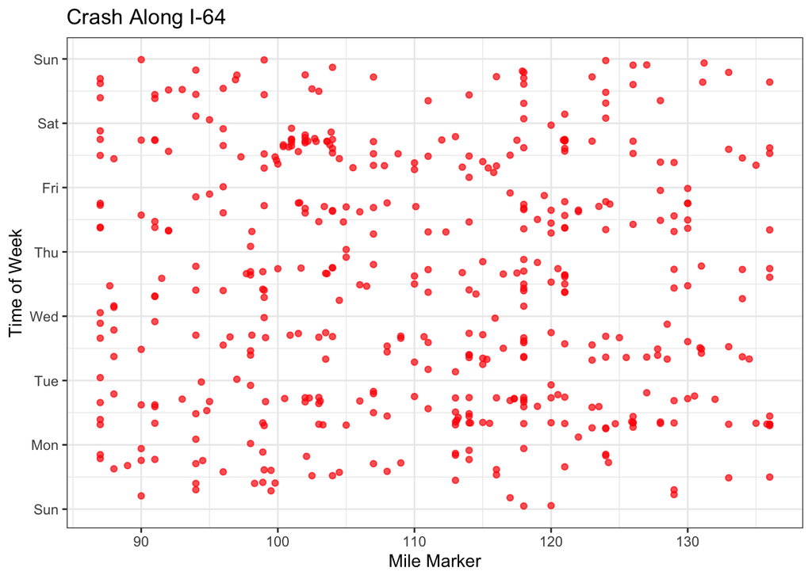

```r
library(ggplot2)
ggplot(data2, aes(x = mile, y = time)) +
  geom_point(color = "red", alpha = 0.7) +
  labs(
    title = "Crash Along I-64",
    x = "Mile Marker",
    y = "Time of Week"
  ) +
  scale_y_continuous(
    breaks = seq(0, 7, 1),
    labels = c("Sun", "Mon", "Tue", "Wed", "Thu", "Fri", "Sat", "Sun")
  )
```

## b. Use KDE to estimate the *mile marker* density.

- Report the bandwidth.
- Plot the density estimate.

**Solution**

```r
library(ks)

mile_data <- data2$mile
kde <- kde(x = mile_data)

# Calculating Bandwidth
bandwidth <- kde$H
cat("The bandwidth used for the KDE is:\n")
```

```
The bandwidth used for the KDE is:
```

```r
print(bandwidth)
```

```
[1] 8.38
```

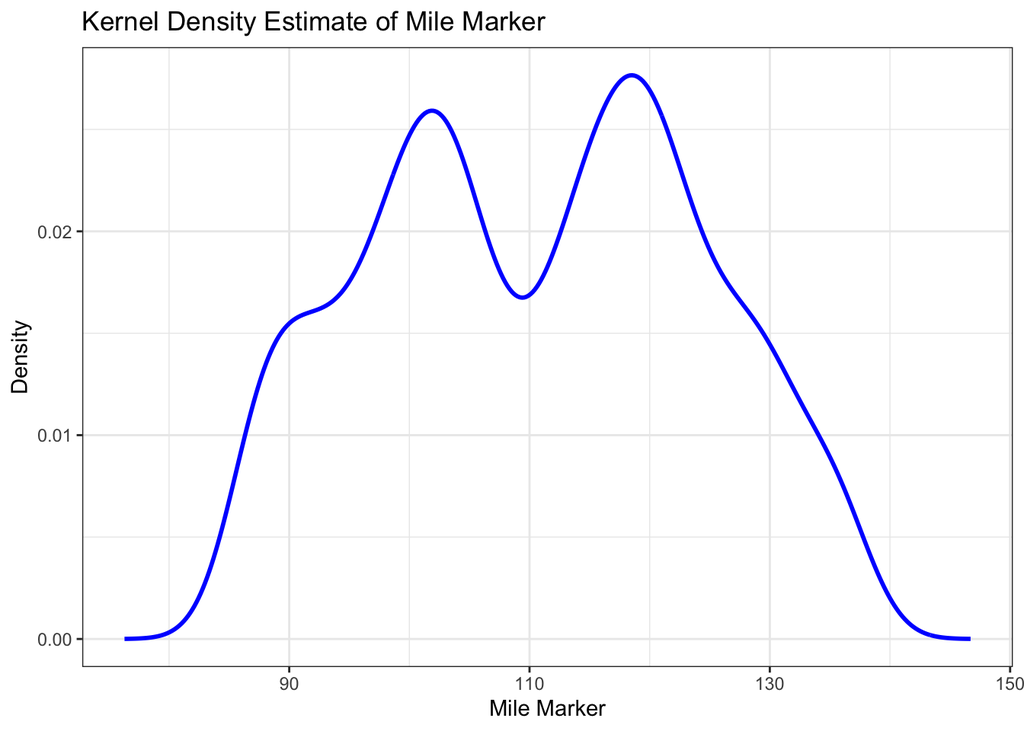

```r
# Creating dataframe
kde_df <- data.frame(
  mile = kde$eval.points,
  density = kde$estimate
)

# Plotting
ggplot(kde_df, aes(x = mile, y = density)) +
  geom_line(color = "blue", size = 1) +
  labs(
    title = "Kernel Density Estimate of Mile Marker",
    x = "Mile Marker",
    y = "Density"
  )
```

## c. Use KDE to estimate the temporal *time-of-week* density.

- Report the bandwidth.
- Plot the density estimate.

**Solution**

```r
time_data <- data2$time

# estimating KDE
kde_time <- kde(x = time_data)
time_bandwidth <- kde_time$H
cat("The bandwidth for the temporal KDE is:\n")
```

```
The bandwidth for the temporal KDE is:
```

```r
print(time_bandwidth)
```

```
[1] 0.172
```

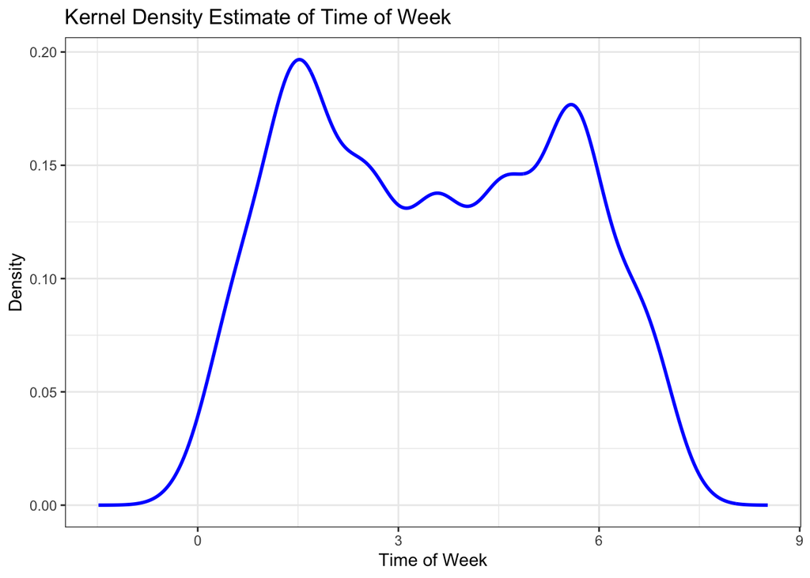

```r
# Convert data to dataframe
kde_time_df <- data.frame(
  time = kde_time$eval.points,
  density = kde_time$estimate
)

# Plotting
ggplot(kde_time_df, aes(x = time, y = density)) +
  geom_line(color = "blue", size = 1) +
  labs(
    title = "Kernel Density Estimate of Time of Week",
    x = "Time of Week",
    y = "Density"
  )
```

## d. Use KDE to estimate the bivariate mile-time density.

- Report the bandwidth parameters.
- Plot the bivariate density estimate.

**Solution**

```r
mile_time_data <- data2[, c("mile", "time")]

# KDE estimation
kde_bivariate <- kde(x = as.matrix(mile_time_data))
bandwidth_matrix <- kde_bivariate$H
cat("The bandwidth for the bivariate KDE is:\n")
```

```
The bandwidth for the bivariate KDE is:
```

```r
print(bandwidth_matrix)
```

```
       [,1]   [,2]
[1,] 19.045 -0.115
[2,] -0.115  0.330
```

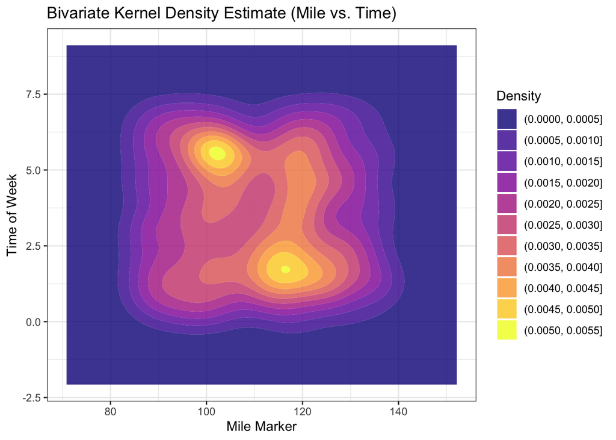

```r
# Convert data to dataframe
kde_bivariate_df <- data.frame(
  expand.grid(mile = kde_bivariate$eval.points[[1]], time = kde_bivariate$eval.points[[2]]),
  density = as.vector(kde_bivariate$estimate)
)

# Plotting
ggplot(kde_bivariate_df, aes(x = mile, y = time, z = density)) +
  geom_contour_filled(aes(fill = after_stat(level)), alpha = 0.8) +
  scale_fill_viridis_d(option = "plasma") + # Use the discrete scale
  labs(
    title = "Bivariate Kernel Density Estimate (Mile vs. Time)",
    x = "Mile Marker",
    y = "Time of Week",
    fill = "Density"
  )
```

## e. Crash Hotspot

Based on the estimated density, approximate the most dangerous place and time to drive on this stretch of road. Identify the mile marker and time-of-week pair (within a few miles and hours).

**Solution**